# ELMER workshop

## Introduction

### Workshop Description

This workshop demonstrates how to perform ELMER analysis using matched RNA-seq and DNA methylation data.

You can find a detailed information about ELMER at http://bioconductor.org/packages/3.10/bioc/vignettes/ELMER/inst/doc/index.html.

Articles about ELMER:

- Tiago C Silva, Simon G Coetzee, Nicole Gull, Lijing Yao, Dennis J Hazelett, Houtan Noushmehr, De-Chen Lin, Benjamin P Berman, ELMER v.2: an R/Bioconductor package to reconstruct gene regulatory networks from DNA methylation and transcriptome profiles, Bioinformatics, Volume 35, Issue 11, 1 June 2019, Pages 1974–1977, https://doi.org/10.1093/bioinformatics/bty902
- Yao, Lijing, et al. "Inferring regulatory element landscapes and transcription factor networks from cancer methylomes." Genome biology 16.1 (2015): 105. https://doi.org/10.1186/s13059-015-0668-3
- Yao, Lijing, Benjamin P. Berman, and Peggy J. Farnham. "Demystifying the secret mission of enhancers: linking distal regulatory elements to target genes." Critical reviews in biochemistry and molecular biology 50.6 (2015): 550-573. https://doi.org/10.3109/10409238.2015.1087961

### Material

- Workshop HTML: http://rpubs.com/tiagochst/500982
- The data is available in this [google drive](https://drive.google.com/drive/folders/1N9GKy8rEdmNsPa3W1vZ7WnBaUlXky2L4?usp=sharing).

### Pre-requisites

- Basic knowledge of R syntax
- Familiarity with the `SummarizedExperiment` classes
- Familiarity with ’omics data types including DNA methylation and gene expression

### Workshop Participation

Students will have a chance to run ELMER analysis on a provided `MultiAssayExperiment` object created from TCGA data from GDC data portal.

### Goals and objectives

- gain familiarity ELMER input data, a `MultiAssayExperiment` object
- Execute ELMER analysis on real data and understand its meaning

### Main R/Bioconductor packages used

- [ELMER](http://bioconductor.org/packages/ELMER/)
- [MultiAssayExperiment](http://bioconductor.org/packages/MultiAssayExperiment/)
- [ComplexHeatmap](http://bioconductor.org/packages/ComplexHeatmap/)

## Starting ELMER analysis

### Loading libraries

First, we need to load the R packages used in this workshop, they should provide the required functions to run the code.

```r
suppressMessages({
    library("ELMER")
    library("MultiAssayExperiment")
})
```

### ELMER input data

The RNA-seq data, DNA methylation data and patients metadata (i.e age, gender) used in this workshop is structured as a `MultiAssayExperiment`. You can read more about a `MultiAssayExperiment` object at http://bioconductor.org/packages/MultiAssayExperiment/ and https://bioconductor.github.io/BiocWorkshops/workflow-for-multi-omics-analysis-with-multiassayexperiment.html.

Through the next section we will:

1. Load the data
2. Verify the RNA-seq data
3. Verify the DNA methylation data
4. Verify the samples metadata

### Loading the data

The data which is available in this machine, can also be downloaded at this [google drive](https://drive.google.com/drive/folders/1N9GKy8rEdmNsPa3W1vZ7WnBaUlXky2L4?usp=sharing).

```r
# Dowloaded at
# https://drive.google.com/open?id=1fPKEG7c_uFoofyhQ4EkW1e2SMZmr6XUt
mae <- readRDS("Data/reduced_TCGA_ESCA_MAE_distal_regions.rds")
mae
colnames(mae)
```

```
A MultiAssayExperiment object of 2 listed
 experiments with user-defined names and respective classes.
 Containing an ExperimentList class object of length 2:
 [1] DNA methylation: RangedSummarizedExperiment with 9731 rows and 171 columns
 [2] Gene expression: RangedSummarizedExperiment with 56830 rows and 171 columns
Features:
 experiments() - obtain the ExperimentList instance
 colData() - the primary/phenotype DataFrame
 sampleMap() - the sample availability DataFrame
 `$`, `[`, `[[` - extract colData columns, subset, or experiment
 *Format() - convert into a long or wide DataFrame
 assays() - convert ExperimentList to a SimpleList of matrices
```

```
CharacterList of length 2
[["DNA methylation"]] TCGA-2H-A9GF-01A-11D-A37D-05 ...
[["Gene expression"]] TCGA-2H-A9GF-01A-11R-A37I-31 ...
```

### Check RNA-seq object

```r
# check experiments
experiments(mae)
```

```
ExperimentList class object of length 2:
 [1] DNA methylation: RangedSummarizedExperiment with 9731 rows and 171 columns
 [2] Gene expression: RangedSummarizedExperiment with 56830 rows and 171 columns
```

```r
# Get the Gene expression object
rna.seq <- mae[[2]]

message("Number of genes ",nrow(rna.seq))

message("Number of samples ",ncol(rna.seq))

message("Check genes metadata")
rowRanges(rna.seq)

message("Check gene expression data")
assay(rna.seq)[1:4,1:4]
```

```
Number of genes 56830
Number of samples 171
Check genes metadata
```

```
GRanges object with 56830 ranges and 3 metadata columns:
                  seqnames              ranges strand | ensembl_gene_id
                     <Rle>           <IRanges>  <Rle> |     <character>
  ENSG00000000003     chrX 100627109-100639991      - | ENSG00000000003
  ENSG00000000005     chrX 100584802-100599885      + | ENSG00000000005
  ENSG00000000419    chr20   50934867-50958555      - | ENSG00000000419
  ENSG00000000457     chr1 169849631-169894267      - | ENSG00000000457
  ENSG00000000460     chr1 169662007-169854080      + | ENSG00000000460
              ...      ...                 ...    ... .             ...
  ENSG00000281904     chr2   90365737-90367699      + | ENSG00000281904
  ENSG00000281909    chr15   22480439-22484840      - | ENSG00000281909
  ENSG00000281910    chr16   58559796-58559931      - | ENSG00000281910
  ENSG00000281912     chr1   45303910-45305619      + | ENSG00000281912
  ENSG00000281920     chr2   65623272-65628424      + | ENSG00000281920
                  external_gene_name original_ensembl_gene_id
                         <character>              <character>
  ENSG00000000003             TSPAN6       ENSG00000000003.13
  ENSG00000000005               TNMD        ENSG00000000005.5
  ENSG00000000419               DPM1       ENSG00000000419.11
  ENSG00000000457              SCYL3       ENSG00000000457.12
  ENSG00000000460           C1orf112       ENSG00000000460.15
              ...                ...                      ...
  ENSG00000281904         AC233263.6        ENSG00000281904.1
  ENSG00000281909            HERC2P7        ENSG00000281909.1
  ENSG00000281910           SNORA50A        ENSG00000281910.1
  ENSG00000281912          LINC01144        ENSG00000281912.1
  ENSG00000281920         AC007389.5        ENSG00000281920.1
  -------
  seqinfo: 24 sequences from an unspecified genome; no seqlengths
```

```
Check gene expression data
```

A matrix: 4 × 4 of type dbl

|  | TCGA-2H-A9GF-01A-11R-A37I-31 | TCGA-2H-A9GG-01A-11R-A37I-31 | TCGA-2H-A9GH-01A-11R-A37I-31 | TCGA-2H-A9GI-01A-11R-A37I-31 |
| --- | --- | --- | --- | --- |
| ENSG00000000003 | 17.63165 | 16.758267 | 17.624508 | 17.89604 |
| ENSG00000000005 | 0.00000 | 7.721927 | 9.236257 | 0.00000 |
| ENSG00000000419 | 19.33125 | 19.188030 | 19.765411 | 20.90188 |
| ENSG00000000457 | 15.87565 | 16.251205 | 15.745243 | 15.92405 |

### Check DNA methylation data

```r
# Get the DNA methylation object
dna.met <- mae[[1]]

# This is a reduced version of the distal probes to be run in a Machine with low memory
message("Number of probes: ", nrow(dna.met))
message("Number of samples: ", ncol(dna.met))


message("Check DNA methylation probes metadata")
rowRanges(dna.met)[,1:4]

message("Check DNA methylation beta values")
assay(dna.met)[1:4,1:4]
```

```
Number of probes: 9731
Number of samples: 171
Check DNA methylation probes metadata
```

```
GRanges object with 9731 ranges and 4 metadata columns:
             seqnames              ranges strand | address_A address_B
                <Rle>           <IRanges>  <Rle> | <integer> <integer>
  cg10176463     chr1     1005402-1005403      + |  49603311  53707307
  cg19860160     chr1     1110002-1110003      + |  49767375      <NA>
  cg26405545     chr1     1110126-1110127      - |  74767399      <NA>
  cg06798288     chr1     1127806-1127807      - |  42777325      <NA>
  cg02838683     chr1     1128477-1128478      + |  18745398      <NA>
         ...      ...                 ...    ... .       ...       ...
  cg26457165     chrX 153411868-153411869      + |  61794314  30751493
  cg04960964     chrX 153411925-153411926      + |  44810405      <NA>
  cg17330458     chrX 153442220-153442221      - |  48793342      <NA>
  cg24926947     chrX 154807851-154807852      + |  30620453      <NA>
  cg25059696     chrY     7563149-7563150      + |  61613414      <NA>
                 channel  designType
             <character> <character>
  cg10176463         Red           I
  cg19860160        Both          II
  cg26405545        Both          II
  cg06798288        Both          II
  cg02838683        Both          II
         ...         ...         ...
  cg26457165         Grn           I
  cg04960964        Both          II
  cg17330458        Both          II
  cg24926947        Both          II
  cg25059696        Both          II
  -------
  seqinfo: 26 sequences from an unspecified genome; no seqlengths
```

```
Check DNA methylation beta values
```

A matrix: 4 × 4 of type dbl

|  | TCGA-2H-A9GF-01A-11D-A37D-05 | TCGA-2H-A9GG-01A-11D-A37D-05 | TCGA-2H-A9GH-01A-11D-A37D-05 | TCGA-2H-A9GI-01A-11D-A37D-05 |
| --- | --- | --- | --- | --- |
| cg10176463 | 0.01312852 | 0.09647309 | 0.02828287 | 0.03016274 |
| cg19860160 | 0.23160755 | 0.82488337 | 0.31041358 | 0.36574189 |
| cg26405545 | 0.38807854 | 0.82018722 | 0.49493688 | 0.53038315 |
| cg06798288 | 0.67245217 | 0.49902193 | 0.38497135 | 0.39046920 |

### Check samples metadata

```r
message("metadata can be accessed using the function colData")
message("we will check the first 4 samples and their 4 columns")
colData(mae)[1:4,1:4]

message("or you can also access the metadata directly with the $")
mae$primary_diagnosis[1:4]

message("summarize the number of tissue type with the function table")
table(mae$definition)

message("summarize the numbers of samples using two features")
table(mae$primary_diagnosis,mae$definition)
```

```
metadata can be accessed using the function colData
we will check the first 4 samples and their 4 columns
```

```
DataFrame with 4 rows and 4 columns
                           sample      patient shortLetterCode
                      <character>  <character>     <character>
TCGA-2H-A9GF-01A TCGA-2H-A9GF-01A TCGA-2H-A9GF              TP
TCGA-2H-A9GG-01A TCGA-2H-A9GG-01A TCGA-2H-A9GG              TP
TCGA-2H-A9GH-01A TCGA-2H-A9GH-01A TCGA-2H-A9GH              TP
TCGA-2H-A9GI-01A TCGA-2H-A9GI-01A TCGA-2H-A9GI              TP
                          definition
                         <character>
TCGA-2H-A9GF-01A Primary solid Tumor
TCGA-2H-A9GG-01A Primary solid Tumor
TCGA-2H-A9GH-01A Primary solid Tumor
TCGA-2H-A9GI-01A Primary solid Tumor
```

```
or you can also access the metadata directly with the $
```

1. 'Adenocarcinoma, NOS'

2. 'Adenocarcinoma, NOS'

3. 'Adenocarcinoma, NOS'

4. 'Adenocarcinoma, NOS'

```
summarize the number of tissue type with the function table
```

```
         Metastatic Primary solid Tumor Solid Tissue Normal
                  1                 161                   9
```

```
summarize the numbers of samples using two features
```

```
                                             Metastatic Primary solid Tumor
  Adenocarcinoma, NOS                                 0                  78
  Basaloid squamous cell carcinoma                    0                   1
  Mucinous adenocarcinoma                             0                   1
  Squamous cell carcinoma, keratinizing, NOS          0                   4
  Squamous cell carcinoma, NOS                        1                  76
  Tubular adenocarcinoma                              0                   1

                                             Solid Tissue Normal
  Adenocarcinoma, NOS                                          7
  Basaloid squamous cell carcinoma                             0
  Mucinous adenocarcinoma                                      1
  Squamous cell carcinoma, keratinizing, NOS                   0
  Squamous cell carcinoma, NOS                                 1
  Tubular adenocarcinoma                                       0
```

### Selecting the samples

Since we will use only Primary solid Tumor samples we will remove the Metastatic and Solid Tissue Normal samples from our object

```r
mae <- mae[, mae$definition == "Primary solid Tumor"]
```

## Performing ELMER analysis

```r
# which is the column of the samples metadata defining our groups
group.col <- "primary_diagnosis"

# which are the grops withing the group.col that we want to compare
group1 <- "Adenocarcinoma, NOS"
group2 <- "Squamous cell carcinoma, NOS"

# Identify probes hypo in group1 or hypo in group2 ?
direction <- "hypo" # hypo in group 1

cores <- 2
mode <- "supervised"

# Where do we want to save the results ?
dir.out <- paste0("analysis_reduced/",group.col,"-",
                  gsub("[[:punct:]]| ", "_", group1),
                  "_vs_",
                  gsub("[[:punct:]]| ", "_", group2),
                  "_", mode,
                  "/", direction)
message("Results will be saved at: ",dir.out)
dir.create(dir.out, showWarnings = FALSE,recursive = T)
```

```
Results will be saved at: analysis_reduced/primary_diagnosis-Adenocarcinoma__NOS_vs_Squamous_cell_carcinoma__NOS_supervised/hypo
```

## Identifying hypo methylated distal probes between ESAD samples compared to ESCC samples

```r
# time expected with one core: 4 minuntes
diff.probes <- get.diff.meth(data = mae,
                             group.col = group.col,
                             group1 = group1,
                             group2 = group2,
                             diff.dir = direction, # Get probes hypometh. in group 1
                             cores = cores,
                             mode = mode,
                             pvalue = 0.01,
                             sig.dif = 0.3,
                             dir.out =  dir.out,
                             save = TRUE)
# check the results
head(diff.probes)
```

```
Supervised mode will use all samples from boths groups. Setting argument minSubgroupFrac to 1
ELMER will search for probes hypomethylated in group Adenocarcinoma, NOS (n:78) compared to Squamous cell carcinoma, NOS (n:76)
ooo Arguments ooo
o Number of probes: 9731
o Beta value difference cut-off: 0.3
o FDR cut-off: 0.01
o Mode: supervised
o % of samples per group in each comparison: 1
o Min number of samples per group in each comparison: 5
o Nb of samples group1 in each comparison: 78
o Nb of samples group2 in each comparison: 76
Output direction: analysis_reduced/primary_diagnosis-Adenocarcinoma__NOS_vs_Squamous_cell_carcinoma__NOS_supervised/hypo
ooooooooooooooooo
Progress disabled when using parallel plyr
Warning message in setup_parallel():
"No parallel backend registered"Saving results
Number of relevant probes found: 1524
```

A data.frame: 6 × 4

|  | probe <chr> | pvalue <dbl> | Adenocarcinoma..NOS_Minus_Squamous.cell.carcinoma..NOS <dbl> | adjust.p <dbl> |
| --- | --- | --- | --- | --- |
| cg19860160 | cg19860160 | 3.178629e-41 | -0.4256266 | 3.124367e-39 |
| cg02838683 | cg02838683 | 7.322499e-46 | -0.3138876 | 1.583450e-43 |
| cg22512779 | cg22512779 | 1.305816e-45 | -0.3538253 | 2.760300e-43 |
| cg17094363 | cg17094363 | 4.500204e-35 | -0.4751664 | 1.552889e-33 |
| cg20429981 | cg20429981 | 1.834374e-22 | -0.3227621 | 1.187644e-21 |
| cg01189072 | cg01189072 | 9.596881e-18 | -0.3771010 | 3.524047e-17 |

## Correlate RNA-seq expression and DNA methylation

Now that we have our hypomethylated probes we will look for the 20 nearest genes  
to each probes to identify if any of these genes could being affected by the hypomethylation in the distal regulatory region.

```r
# time expected less than one minute
nearGenes <- GetNearGenes(data = mae,
                          probes =  diff.probes$probe,
                          numFlankingGenes = 20)
head(nearGenes)
```

```
Searching for the 20 near genes
Identifying gene position for each probe
```

A grouped_df: 6 × 5

| ID <chr> | GeneID <chr> | Symbol <chr> | Distance <dbl> | Side <chr> |
| --- | --- | --- | --- | --- |
| cg00009553 | ENSG00000261590 | AC018554.2 | -1462705 | L10 |
| cg00009553 | ENSG00000278499 | AC018554.3 | -1460699 | L9 |
| cg00009553 | ENSG00000261436 | AC018554.1 | -1377934 | L8 |
| cg00009553 | ENSG00000261310 | AC009081.1 | -1296929 | L7 |
| cg00009553 | ENSG00000259844 | GNPATP | -1163530 | L6 |
| cg00009553 | ENSG00000261178 | AC009169.1 | -891638 | L5 |

Now that we have our hypomethylated probes and the 20 nearest genes we want to identify if any of these genes could being affected by the hypomethylatio in the distal regulatory region.

```r
# time expected  one minute
pair <- get.pair(data = mae,
                 nearGenes = nearGenes,
                 group.col = group.col,
                 group1 = group1,
                 group2 = group2,
                 mode = mode,
                 diff.dir = direction,
                 raw.pvalue = 0.001,
                 Pe = 0.001,
                 filter.probes = TRUE,
                 filter.percentage = 0.05,
                 filter.portion = 0.3,
                 dir.out =  dir.out,
                 cores = cores,
                 label = direction)

head(pair)
```

```
Using pre-defined groups. U (unmethylated): Adenocarcinoma, NOS, M (methylated): Squamous cell carcinoma, NOS
-------------------
* Filtering probes
-------------------
For more information see function preAssociationProbeFiltering
Making sure we have at least 5% of beta values lesser than 0.3 and 5% of beta values greater 0.3.
Removing 2093 probes out of 9731
Calculating Pp (probe - gene) for all nearby genes
Progress disabled when using parallel plyr
Warning message in setup_parallel():
"No parallel backend registered"File created: analysis_reduced/primary_diagnosis-Adenocarcinoma__NOS_vs_Squamous_cell_carcinoma__NOS_supervised/hypo/getPair.hypo.all.pairs.statistic.csv
```

A data.frame: 6 × 7

|  | Probe <chr> | GeneID <chr> | Symbol <chr> | Distance <dbl> | Sides <chr> | Raw.p <dbl> | FDR <dbl> |
| --- | --- | --- | --- | --- | --- | --- | --- |
| cg13100118.ENSG00000178828 | cg13100118 | ENSG00000178828 | RNF186 | 345152 | R9 | 4.334152e-27 | 3.345954e-24 |
| cg19533443.ENSG00000173702 | cg19533443 | ENSG00000173702 | MUC13 | -38437 | L2 | 6.023782e-27 | 3.345954e-24 |
| cg14981432.ENSG00000124920 | cg14981432 | ENSG00000124920 | MYRF | 0 | L1 | 7.607601e-27 | 3.345954e-24 |
| cg26545245.ENSG00000166866 | cg26545245 | ENSG00000166866 | MYO1A | 40016 | R4 | 7.909052e-27 | 3.345954e-24 |
| cg17277896.ENSG00000143375 | cg17277896 | ENSG00000143375 | CGN | 37443 | R1 | 8.886298e-27 | 3.345954e-24 |
| cg21157873.ENSG00000143375 | cg21157873 | ENSG00000143375 | CGN | 0 | L1 | 8.886298e-27 | 3.345954e-24 |

We can plot the correlation heatmap of DNA methylation and gene expression with the `heatmapPairs` function. We will plot only the first 100 pairs.

```
Subsetting
Ordering groups
```

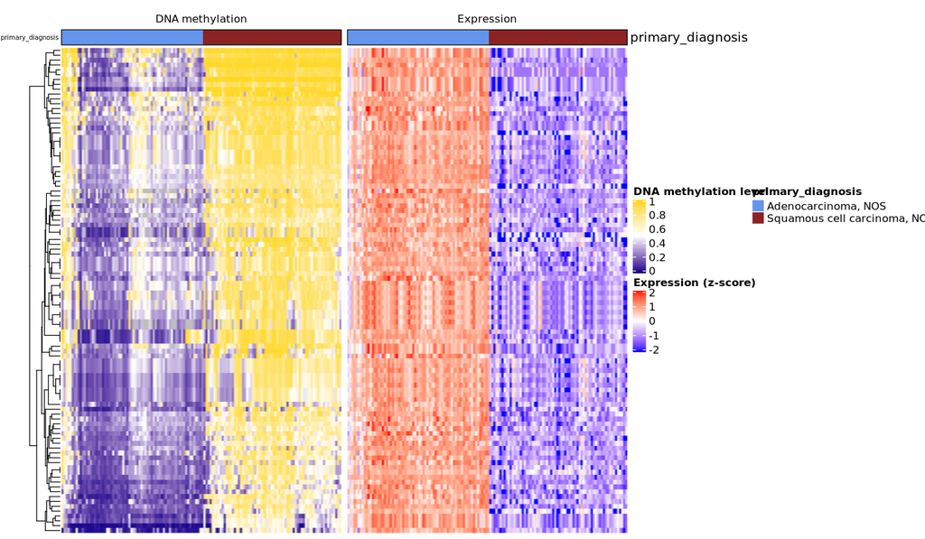

```r
# Plot size options
options(repr.plot.width=12, repr.plot.height=7)


heatmapPairs(data = mae,
             group.col = group.col,
             group1 = group1,
             group2 = group2,
             subset = TRUE,
             pairs = pair[1:100,],
             filename =  NULL)
```

## Identifying TF enriched motifs on the hypomethylated regions

We have hypomethylated regions that has a distal gene upregulated. We want to identify which is the MR TF binding to those regions and regulating the distal gene. First we identify which are the enriched motifs for those hypomethylated regions using the function `get.enriched.motif`. This will output the enriched motifs and the respective hypomethylated probes with the motif signature around it (since a DNA methylation probes is 1bp, we extended the search window to $\pm$ 250 bp).

```r
# time expected  less than one minute
distal.probes <- get.feature.probe(feature = NULL,
                                   genome = "hg38",
                                   met.platform = "450K")

enriched.motif <- get.enriched.motif(probes.motif = ELMER:::getdata("Probes.motif.hg38.450K"),
                                     background.probes = names(distal.probes),
                                     probes = unique(pair$Probe),
                                     dir.out = dir.out,
                                     label = direction,
                                     min.incidence = 10,
                                     lower.OR = 1.5)
```

```
Returning distal probes: 160862
```

```
|====================================================|100%                      Completed after 7 s
```

```
Retrieving TFClass family classification from ELMER.data.
Retrieving TFClass subfamily classification from ELMER.data.
------------------------------------
** Filtering motifs based on quality
------------------------------------
Number of enriched motifs with quality:
-----------
 => A: 18
 => B: 4
 => C: 4
 => D: 5
 => S: 0
-----------
Considering only motifs with quality from A up to DS: 31 motifs are enriched.
---------------------------------------------------
* Adding enriched motifs to significant pairs file
---------------------------------------------------
Saving file: analysis_reduced/primary_diagnosis-Adenocarcinoma__NOS_vs_Squamous_cell_carcinoma__NOS_supervised/hypo/getPair.hypo.pairs.significant.withmotif.csv
```

```
check top 5 enriched motifs
```

1. 'HNF4A_HUMAN.H11MO.0.A'

2. 'GATA4_HUMAN.H11MO.0.A'

3. 'GATA6_HUMAN.H11MO.0.A'

4. 'GATA2_HUMAN.H11MO.1.A'

5. 'GATA1_HUMAN.H11MO.1.A'

```
Check the paired hypomethylated probes with the motif signature
```

1. 'cg22050733'

2. 'cg04275506'

3. 'cg19860160'

4. 'cg22512779'

5. 'cg19626253'

6. 'cg03601886'

7. 'cg13784017'

8. 'cg11959316'

9. 'cg07191152'

10. 'cg25098793'

11. 'cg05625834'

12. 'cg17277896'

13. 'cg26787863'

14. 'cg00075975'

15. 'cg07005353'

16. 'cg00577847'

17. 'cg07117596'

18. 'cg14520947'

19. 'cg23486701'

20. 'cg22107147'

21. 'cg20043649'

22. 'cg08818866'

23. 'cg08847775'

24. 'cg12077754'

25. 'cg27239243'

26. 'cg10560561'

27. 'cg05977696'

28. 'cg23367358'

29. 'cg10018933'

30. 'cg21926118'

31. 'cg07613752'

32. 'cg01450522'

33. 'cg24590723'

34. 'cg03865925'

35. 'cg18342703'

36. 'cg21425296'

37. 'cg00584840'

38. 'cg23174148'

39. 'cg22539744'

40. 'cg01377807'

41. 'cg04319611'

42. 'cg11578055'

43. 'cg15634747'

44. 'cg23971987'

45. 'cg01923775'

46. 'cg05626226'

47. 'cg03464224'

48. 'cg00796302'

49. 'cg26728709'

50. 'cg08988420'

51. 'cg08830157'

52. 'cg18430895'

53. 'cg08609445'

54. 'cg16016281'

55. 'cg11821200'

56. 'cg24606701'

57. 'cg27351783'

58. 'cg21566177'

59. 'cg03172688'

60. 'cg10505610'

61. 'cg11584098'

62. 'cg19692192'

63. 'cg05165087'

64. 'cg07186962'

65. 'cg08015382'

66. 'cg27565517'

67. 'cg15094236'

68. 'cg12663302'

69. 'cg23381884'

70. 'cg14493742'

71. 'cg09305161'

72. 'cg10846969'

73. 'cg23226631'

74. 'cg10784258'

75. 'cg22443940'

76. 'cg19929194'

77. 'cg12964881'

78. 'cg24645679'

79. 'cg00084338'

80. 'cg17287122'

81. 'cg27246129'

82. 'cg09022230'

83. 'cg00772192'

84. 'cg02498579'

85. 'cg08828787'

86. 'cg14033170'

87. 'cg18100008'

88. 'cg09422239'

89. 'cg15059474'

90. 'cg24300607'

91. 'cg19935531'

92. 'cg14199261'

93. 'cg05921889'

94. 'cg05744395'

95. 'cg18991321'

96. 'cg00987534'

97. 'cg02901002'

98. 'cg12018521'

99. 'cg01824603'

100. 'cg10087556'

101. 'cg14533298'

102. 'cg17291136'

103. 'cg04237288'

104. 'cg18336854'

105. 'cg12726213'

106. 'cg24027477'

107. 'cg15235922'

108. 'cg07273304'

109. 'cg26895804'

110. 'cg10131026'

111. 'cg14325112'

112. 'cg03489427'

113. 'cg10063407'

114. 'cg01364755'

115. 'cg14509153'

116. 'cg10476206'

117. 'cg17568611'

118. 'cg23681599'

119. 'cg10494981'

120. 'cg25227803'

121. 'cg27065896'

122. 'cg11688410'

123. 'cg17425818'

124. 'cg04337594'

125. 'cg18203466'

126. 'cg10955669'

127. 'cg19754622'

128. 'cg13608733'

129. 'cg26725502'

130. 'cg16311302'

131. 'cg15722533'

132. 'cg20482760'

133. 'cg23091777'

134. 'cg03078767'

135. 'cg02856190'

136. 'cg25015613'

137. 'cg15110243'

138. 'cg18246298'

139. 'cg02159731'

140. 'cg06978117'

141. 'cg23327896'

142. 'cg16182447'

143. 'cg26540315'

144. 'cg18248586'

145. 'cg03554573'

146. 'cg21127079'

147. 'cg21672401'

148. 'cg21738443'

149. 'cg25757470'

150. 'cg17046586'

151. 'cg19091779'

152. 'cg01579458'

153. 'cg10621809'

154. 'cg17066349'

155. 'cg27614751'

156. 'cg26545245'

157. 'cg04874286'

158. 'cg11658060'

159. 'cg13712197'

160. 'cg17843665'

161. 'cg20360395'

162. 'cg16378261'

163. 'cg12194594'

164. 'cg16536610'

165. 'cg12128696'

166. 'cg13995599'

167. 'cg02909176'

168. 'cg16217297'

169. 'cg07800658'

170. 'cg15935770'

171. 'cg23639055'

172. 'cg14850604'

173. 'cg21207694'

174. 'cg19708418'

175. 'cg13594138'

176. 'cg21523688'

177. 'cg04094640'

178. 'cg09113939'

179. 'cg07092029'

180. 'cg07098502'

181. 'cg10020890'

182. 'cg00599850'

183. 'cg13688786'

184. 'cg04726374'

185. 'cg04136369'

186. 'cg08659204'

187. 'cg03828329'

188. 'cg04770088'

189. 'cg04603419'

190. 'cg17415265'

191. 'cg00777445'

192. 'cg19078037'

193. 'cg00423871'

194. 'cg09926389'

195. 'cg18788725'

196. 'cg07604565'

197. 'cg26162564'

198. 'cg27403406'

199. 'cg21211039'

200. 'cg01327767'

201. 'cg13758960'

202. 'cg05321038'

203. 'cg00389552'

```
Plot enrichement analysis results
```

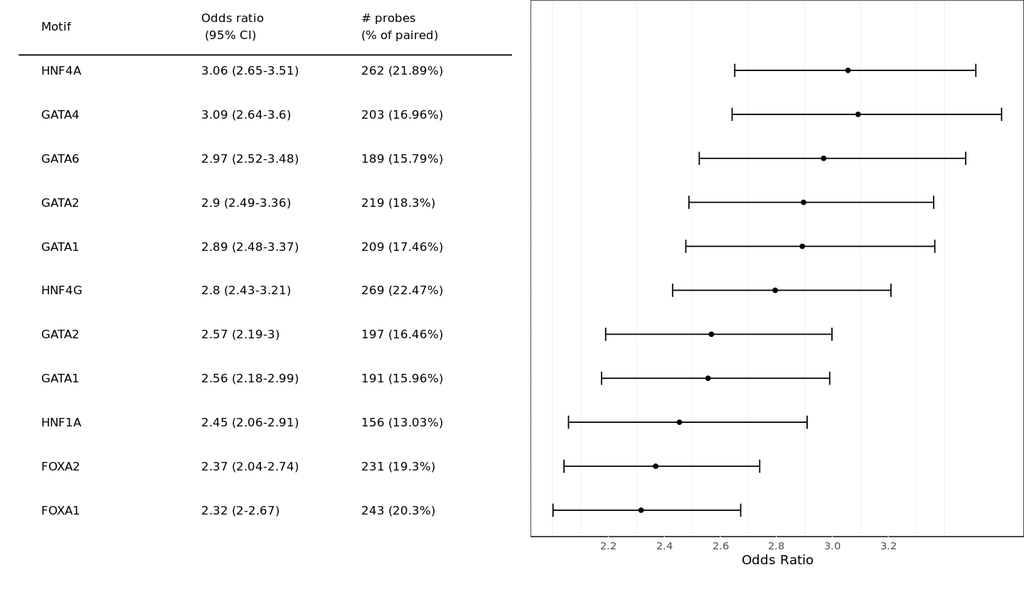

```r
message("check top 5 enriched motifs")
names(enriched.motif)[1:5]

message("Check the paired hypomethylated probes with the motif signature")
enriched.motif$GATA4_HUMAN.H11MO.0.A

message("Plot enrichement analysis results")
motif.result.file <- file.path(dir.out, "getMotif.hypo.motif.enrichment.csv")

# Plot size options
options(repr.plot.width=12, repr.plot.height=7)
motif.enrichment.plot(motif.enrichment = motif.result.file,
                      significant = list(lowerOR = 2.0),
                      label = "hypo",
                      summary = TRUE,
                      save = FALSE)
```

## Inferring MR TF binding to hypomethylated regions

Now that we have our enriched motifs, we have the following question:

- Which is the candidate master regulator Transcription factor binding to those regions ?

It is important to highlight that since TF within the same family and subfamily have very close motifs, they will likely be indentified to bind the same regions. You can check that by verifying the intersection of probes from our enrichment analysis results.

For that ELMER correlates the TF expression vs the average mean methylation of the hypomethylated probes with a motif signature and rank them. We expect that a TF with higher expression and lower methylation in the binding regions will be a better MR TF candidate than TF that are for example equally expressed on both groups.

```r
# time expected  ~5 minutes
TF <- get.TFs(data = mae,
              group.col = group.col,
              mode = mode,
              group1 = group1,
              group2 = group2,
              diff.dir = direction,
              enriched.motif = enriched.motif,
              dir.out = dir.out,
              label = direction,
              cores = cores)
```

```
Using pre-defined groups. U (unmethylated): Adenocarcinoma, NOS, M (methylated): Squamous cell carcinoma, NOS
-------------------------------------------------------------------------------------------------------------------
** Downloading TF list from Lambert, Samuel A., et al. The human transcription factors. Cell 172.4 (2018): 650-665.
-------------------------------------------------------------------------------------------------------------------
Accessing TF families from TFClass database to indentify known potential TF
Retrieving TFClass family classification from ELMER.data.
Retrieving TFClass subfamily classification from ELMER.data.
Calculating the average methylation at all motif-adjacent probes
Progress disabled when using parallel plyr
Warning message in setup_parallel():
"No parallel backend registered"Performing Mann-Whitney U test
Progress disabled when using parallel plyr
Warning message in setup_parallel():
"No parallel backend registered"Finding potential TF and known potential TF
Progress disabled when using parallel plyr
Warning message in setup_parallel():
"No parallel backend registered"
```

```r
message("Check the results for the top 5 enriched motifs")
TF[1:5,1:5]
```

```
Check the results for the top 5 enriched motifs
```

A data.frame: 5 × 5

|  | motif <chr> | top.potential.TF.family <chr> | top.potential.TF.subfamily <chr> | potential.TF.family <chr> | potential.TF.subfamily <chr> |
| --- | --- | --- | --- | --- | --- |
| HNF4A_HUMAN.H11MO.0.A | HNF4A_HUMAN.H11MO.0.A | HNF4A | HNF4A | HNF4A;HNF4G;NR2F2 | HNF4A;HNF4G |
| GATA4_HUMAN.H11MO.0.A | GATA4_HUMAN.H11MO.0.A | GATA6 | GATA6 | GATA6;GATA4 | GATA6;GATA4 |
| GATA6_HUMAN.H11MO.0.A | GATA6_HUMAN.H11MO.0.A | GATA6 | GATA6 | GATA6;GATA4 | GATA6;GATA4 |
| GATA2_HUMAN.H11MO.1.A | GATA2_HUMAN.H11MO.1.A | GATA6 | GATA6 | GATA6;GATA4 | GATA6;GATA4 |
| GATA1_HUMAN.H11MO.1.A | GATA1_HUMAN.H11MO.1.A | GATA6 | GATA6 | GATA6;GATA4 | GATA6;GATA4 |

### Visualizing the results with TF ranking plot

ELMER provides an easy way to visualize the rank of all human TF evaluated with the function `TF.rank.plot`.

```
Retrieving TFClass family classification from ELMER.data.
Retrieving TFClass subfamily classification from ELMER.data.
```

```
|====================================================|100%                      Completed after 0 s
```

```
$HNF4A_HUMAN.H11MO.0.A

attr(,"split_type")
[1] "array"
attr(,"split_labels")
  X1
1  1
```

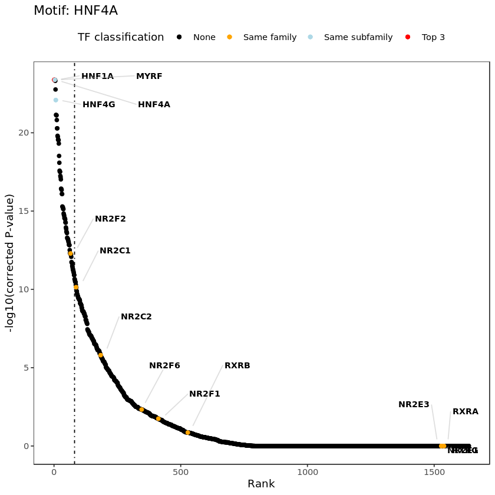

```r
# Plot size options
options(repr.plot.width=7, repr.plot.height=7)

load(file.path(dir.out,"getTF.hypo.TFs.with.motif.pvalue.rda"))

# Ranking plot
# get TF vs avg DNA methylation of the binding sites p-values to be ranked in the plot
load("analysis_reduced/primary_diagnosis-Adenocarcinoma__NOS_vs_Squamous_cell_carcinoma__NOS_supervised/hypo/getTF.hypo.TFs.with.motif.pvalue.rda")
TF.rank.plot(motif.pvalue = TF.meth.cor,
             motif = "HNF4A_HUMAN.H11MO.0.A",
             save = FALSE)
```

```
Retrieving TFClass family classification from ELMER.data.
Retrieving TFClass subfamily classification from ELMER.data.
```

```
|====================================================|100%                      Completed after 0 s
```

```
$GATA4_HUMAN.H11MO.0.A

attr(,"split_type")
[1] "array"
attr(,"split_labels")
  X1
1  1
```

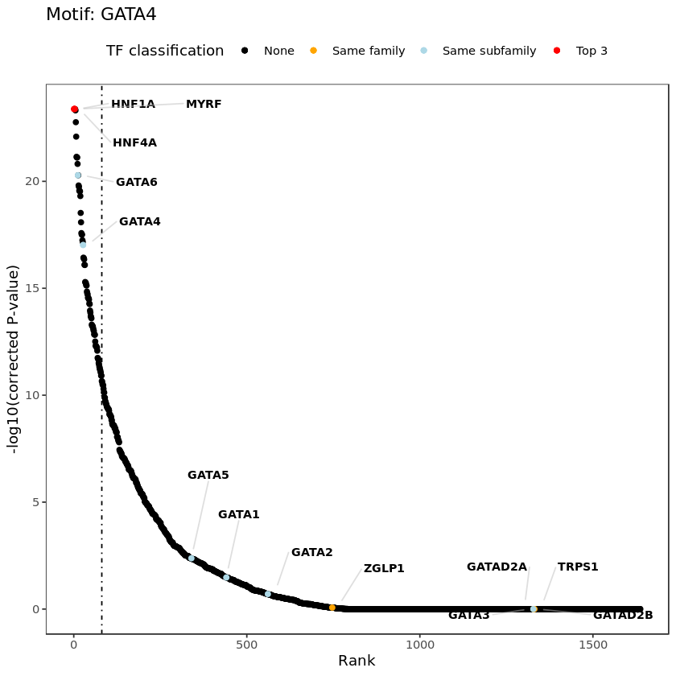

```r
TF.rank.plot(motif.pvalue = TF.meth.cor,
             motif = "GATA4_HUMAN.H11MO.0.A",
             save = FALSE)
```

## Summarizing several ELMER analysis

### MR TF heatmap

When you perform several ELMER analysis with different arguments, you might want to summarize and visualize those several results. For that, we have the `ELMER:::get.tabs` function , which accepts as input the directories of the results and if you want to select the MR TF within the family of subfamily classification.

In the `Data/analysis_april_2019` folder we provided 4 ELMER analysis. The first step is to retrieve the directory names with the results. Also, it is a golden rule when running several ELMER runs to add a understable name to the `dir.out` directories, such that you easily know which analysis were ran, with which arguments. In the example below, you can identify the tumor type, type of ELMER run (supervised/unsupervised), groups compared and direction of the analysis (hypo or hyper in group 1).

```r
analsysis.dir <- unique(dirname(dir("Data/analysis_april_2019/",recursive = T,full.names = T)))
analsysis.dir
```

1. 'Data/analysis_april_2019//COAD-READ/unsupervised/definition-Primary.solid.Tumor_vs_Solid.Tissue.Normal/hypo'

2. 'Data/analysis_april_2019//ESCA/unsupervised/group-Adenocarcinoma.Primary.solid.Tumor_vs_Adenocarcinoma.Solid.Tissue.Normal/hypo'

3. 'Data/analysis_april_2019//ESCA/unsupervised/group-Adenocarcinoma.Primary.solid.Tumor_vs_Squamous.cell.carcinoma.Primary.solid.Tumor/hypo'

4. 'Data/analysis_april_2019//PAAD/unsupervised/definition-Primary.solid.Tumor_vs_Solid.Tissue.Normal/hypo'

With those directory names we will use the function `ELMER:::get.tabs` to summarize the results.

```r
classification <- "subfamily"
suppressWarnings({
    suppressMessages({
        tabs <- ELMER:::get.tabs(analsysis.dir,classification)
    })
})
# A list of matrices are returned
print(class(tabs))

# names of the matrices
print(names(tabs))

# The default it the name directory as column name
tabs$tab[1:3,1:4]

# To be more readable we will change the path names to the analysis name
analysis.names <- c( "COAD-READ (vs Normal)",
                     "EAC (vs Normal)",
                     "EAC (vs ESCC)",
                     "PAAD (vs Normal)")
for (i in 1:3) colnames(tabs[[i]]) <- analysis.names
```

```
[1] "list"
[1] "tab"         "tab.pval"    "tab.or"      "tf.or.table"
```

A data.frame: 3 × 4

|  | Data/analysis_april_2019//COAD-READ/unsupervised/definition-Primary.solid.Tumor_vs_Solid.Tissue.Normal/hypo <dbl> | Data/analysis_april_2019//ESCA/unsupervised/group-Adenocarcinoma.Primary.solid.Tumor_vs_Adenocarcinoma.Solid.Tissue.Normal/hypo <dbl> | Data/analysis_april_2019//ESCA/unsupervised/group-Adenocarcinoma.Primary.solid.Tumor_vs_Squamous.cell.carcinoma.Primary.solid.Tumor/hypo <dbl> | Data/analysis_april_2019//PAAD/unsupervised/definition-Primary.solid.Tumor_vs_Solid.Tissue.Normal/hypo <dbl> |
| --- | --- | --- | --- | --- |
| ARID3A | 1 | 0 | 0 | 0 |
| FOXQ1 | 1 | 0 | 0 | 0 |
| HNF1A | 1 | 1 | 1 | 1 |

This function creates 4 matrices using some of the files in each analysis directory:

1. a binary matrix saying if the TF was found or not in the analysis: this function parses each `getTF.hypo.significant.TFs.with.motif.summary.csv` (create after you run the `get.TFs` function) file that has the MR TF for each enriched motif.

```r
# 1.  a binary matrix saying if the TF was found or not in the analysis
tab.binary <- tabs$tab
head(tab.binary)
```

A data.frame: 6 × 4

|  | COAD-READ (vs Normal) <dbl> | EAC (vs Normal) <dbl> | EAC (vs ESCC) <dbl> | PAAD (vs Normal) <dbl> |
| --- | --- | --- | --- | --- |
| ARID3A | 1 | 0 | 0 | 0 |
| FOXQ1 | 1 | 0 | 0 | 0 |
| HNF1A | 1 | 1 | 1 | 1 |
| PDX1 | 1 | 0 | 0 | 0 |
| POU5F1B | 1 | 0 | 0 | 0 |
| SOX9 | 1 | 0 | 0 | 1 |

1. a matrix with the MR TF p-value found in the analysis: this uses `getTF.hypo.significant.TFs.with.motif.summary.csv` to identify the MR TF and `getTF.hypo.TFs.with.motif.pvalue.rda`, which is a matrix with TF as columns and enriched motifs as rows and the contains the p-value of the wilcoxon test of the TF expression for the Unmethylated vs Methylated groups.

```r
# 2. a matrix  with the MR TF p-value found in the analysis
tab.pval <- tabs$tab.pval
head(tab.pval)
```

A matrix: 6 × 4 of type dbl

|  | COAD-READ (vs Normal) | EAC (vs Normal) | EAC (vs ESCC) | PAAD (vs Normal) |
| --- | --- | --- | --- | --- |
| ARID3A | 8.397450e-08 | NA | NA | NA |
| FOXQ1 | 3.774568e-08 | NA | NA | NA |
| HNF1A | 5.845199e-10 | 0.007700548 | 1.689635e-09 | 1.777426e-07 |
| PDX1 | 3.243946e-09 | NA | NA | NA |
| POU5F1B | 1.259413e-10 | NA | NA | NA |
| SOX9 | 8.410768e-08 | NA | NA | 2.017003e-07 |

1. a matrix with the highest motif OR for the MR TF found in the analysis: this function uses the file `getTF.hypo.significant.TFs.with.motif.summary.csv` to get the MR TF and then uses `getMotif.hypo.motif.enrichment.csv` to get the motifs OR to which the MR TF is known to bind and returns the highest OR.

```r
# 3. a matrix  with the highest motif OR for the MR TF found in the analysis
tab.or <- tabs$tab.or
head(tab.or)
```

A matrix: 6 × 4 of type dbl

|  | COAD-READ (vs Normal) | EAC (vs Normal) | EAC (vs ESCC) | PAAD (vs Normal) |
| --- | --- | --- | --- | --- |
| ARID3A | 1.348007 | NA | NA | NA |
| FOXQ1 | 1.362852 | NA | NA | NA |
| HNF1A | 1.471907 | 1.501869 | 2.190133 | 1.960243 |
| PDX1 | 1.730954 | NA | NA | NA |
| POU5F1B | 1.786492 | NA | NA | NA |
| SOX9 | 1.689930 | NA | NA | 1.684580 |

1. a matrix with 4 collums: MR TF, motif, FDR and analysis it was identified: This function uses the same files as the previous matrices, but returns the results in a different format.

```r
# 4. a matrix  with 4 collums: MR TF, motif, FDR and analysis it was identified.
tf.or.table <- tabs$tf.or.table

# Rename analysis
tf.or.table$analysis <- gsub("ESCA","EAC",paste0(basename(dirname(dirname(dirname(tf.or.table$analysis)))),
                               " (vs ",
                               ifelse(grepl("Normal",tf.or.table$analysis),"Normal","ESCC"),")"))
head(tf.or.table)
```

A data.frame: 6 × 4

|  | TF <chr> | motif <chr> | FDR <dbl> | analysis <chr> |
| --- | --- | --- | --- | --- |
| 7 | ZNF263 | ZIM3_HUMAN.H11MO.0.C | 7.120537e-11 | COAD-READ (vs Normal) |
| 5 | POU5F1B | P5F1B_HUMAN.H11MO.0.D | 1.259413e-10 | COAD-READ (vs Normal) |
| 8 | ZSCAN16 | ZNF85_HUMAN.H11MO.0.C | 3.818943e-10 | COAD-READ (vs Normal) |
| 3 | HNF1A | HNF1B_HUMAN.H11MO.1.A | 5.845199e-10 | COAD-READ (vs Normal) |
| 17 | HNF1A | HNF1B_HUMAN.H11MO.1.A | 1.689635e-09 | EAC (vs ESCC) |
| 21 | FOXA3 | FOXA1_HUMAN.H11MO.0.A | 1.806201e-09 | EAC (vs ESCC) |

## Creating Summary plots

With those summarized results we can create two summary plots:

1. A heatmap with the MR TFs identified in each analysis.
2. A scatter plot of the TF expression vs the avg DNA methylation of the TFBS.

### MR TF heatmap

The code below creates the heatmap using complexHeatmap package for the binary MR TF matrix and the p-value one.

[output not shown]

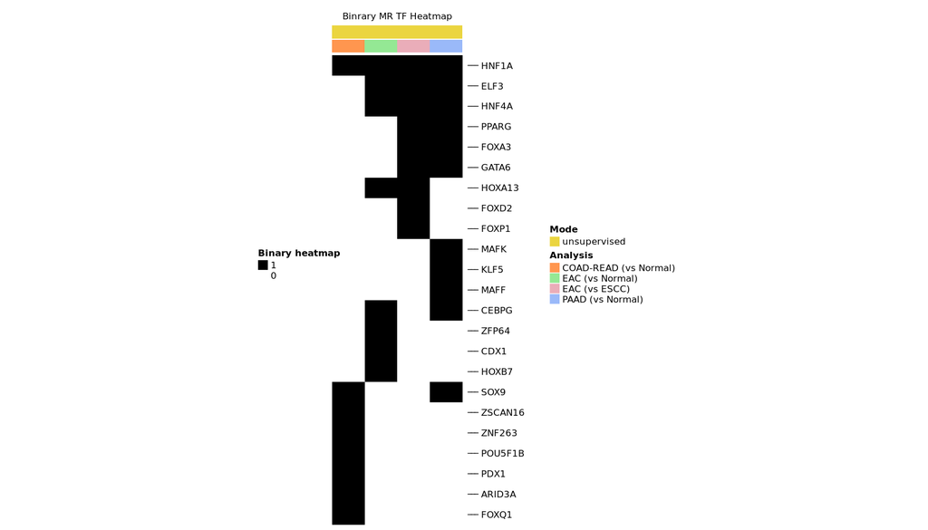

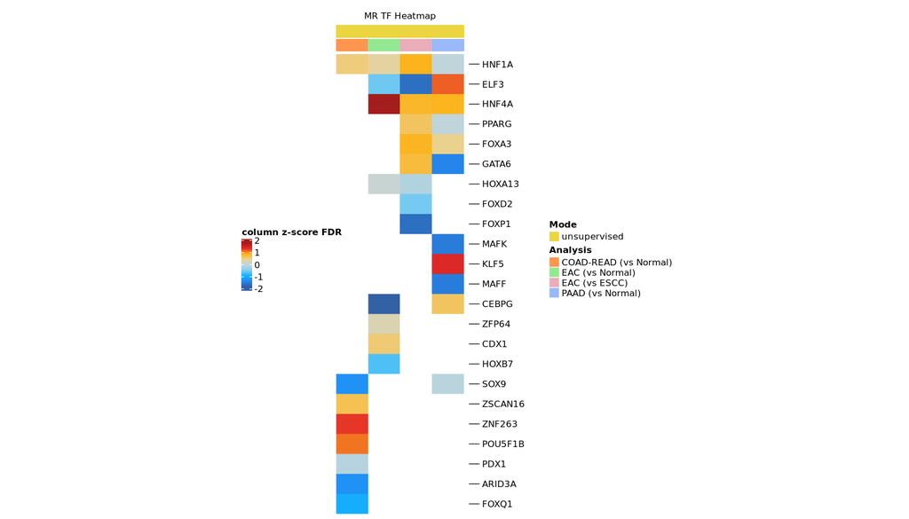

```r
library(ComplexHeatmap)
library(vegan)

options(repr.plot.width=14, repr.plot.height=8)

col <- ifelse(classification == "family","top.potential.TF.family", "top.potential.TF.subfamily")

analysis.colors <- c(
  "COAD-READ (vs Normal)" = '#ff964f',
  "EAC (vs Normal)" = '#94e894',
  "EAC (vs ESCC)" = '#eaadb9',
  "PAAD (vs Normal)" = '#9ab9f9'
)

# get top TFs in each anaylsis
labels <- ELMER:::get.top.tf.by.pval(tab.pval,top = nrow(tab.pval))

# Annotate each column of the matrix (it should be correspondant to the input matrix)
hb = HeatmapAnnotation(df = data.frame("Mode" = rep("unsupervised",4),
                                       "Analysis" = analysis.names),
                       col = list("Analysis" = analysis.colors,
                                  "Mode" = c("unsupervised" = "#ebd540",
                                             "supervised" = "#718da5")),
                       show_annotation_name = FALSE,
                       show_legend = T,
                       annotation_name_side = "left",
                       annotation_name_gp = gpar(fontsize = 12))

# Binary heatmap
ht_list_binary <- Heatmap(as.matrix(tab.binary),
                   name = "Binary heatmap" ,
                   col = c("1" = "black", "0" = "white"),
                   column_names_gp = gpar(fontsize = 8),
                   show_column_names = FALSE,
                   use_raster = TRUE,
                   na_col = "white",
                   raster_device = c("png"),
                   raster_quality = 2,
                   show_row_names = F,
                   show_heatmap_legend = TRUE,
                   cluster_columns = FALSE,
                   cluster_rows = TRUE,
                   show_column_dend = FALSE,
                   show_row_dend = FALSE,
                   clustering_distance_rows = function(x) {
                     vegan::vegdist(tab.binary,method = "jaccard",binary = TRUE)
                   },
                   clustering_method_rows = "average",
                   top_annotation = hb,
                   width = unit(5, "cm"),
                   row_names_gp = gpar(fontsize = 1),
                   column_title = paste0("Binrary MR TF Heatmap"),
                   column_title_gp = gpar(fontsize = 10),
                   row_title_gp = gpar(fontsize = 16))

ht_list_binary <-  ht_list_binary +
  rowAnnotation(link = anno_mark(at = match(labels,rownames(tab.pval)),
                                 labels = labels,labels_gp = gpar(fontsize = 10)),
                width = unit(1, "cm") + max_text_width(labels)
  )
draw(ht_list_binary,
     newpage = FALSE,
     column_title_gp = gpar(fontsize = 12, fontface = "bold"),
     heatmap_legend_side = "left",
     show_heatmap_legend = TRUE,
     annotation_legend_side = "right")

# P-value heatmap
ht_list <- Heatmap(scale(as.matrix(-log10(tab.pval))),
                   name = "column z-score FDR",
                   col = colorRampPalette(c('#3361A5', '#248AF3', '#14B3FF',
                                            '#88CEEF', '#C1D5DC', '#EAD397',
                                            '#FDB31A','#E42A2A', '#A31D1D'))(100),
                   column_names_gp = gpar(fontsize = 8),
                   show_column_names = FALSE,
                   use_raster = TRUE,
                   na_col = "white",
                   raster_device = c("png"),
                   raster_quality = 2,
                   show_row_names = F,
                   show_heatmap_legend = TRUE,
                   cluster_columns = FALSE,
                   cluster_rows = FALSE,
                   row_order = row_order(ht_list_binary),
                   top_annotation = hb,
                   width = unit(5, "cm"),
                   row_names_gp = gpar(fontsize = 1),
                   column_title = paste0("MR TF Heatmap"),
                   column_title_gp = gpar(fontsize = 10),
                   row_title_gp = gpar(fontsize = 16))

ht_list <-  ht_list +
  rowAnnotation(link = anno_mark(at = match(labels,rownames(tab.pval)),
                                 labels = labels,labels_gp = gpar(fontsize = 10)),
                width = unit(1, "cm") + max_text_width(labels)
  )

draw(ht_list,
     newpage = TRUE,
     column_title_gp = gpar(fontsize = 12, fontface = "bold"),
     heatmap_legend_side = "left",
     show_heatmap_legend = TRUE,
     annotation_legend_side = "right")
```

### MR TF expression vs Avg. DNA methylation on TFBS plot

The main difference from the last plot is the requirement of the MAE object with the DNA methylation and gene expression data. For a given MR TF, we need to indentify the top enriched motif it binds and then for each enriched motifs its distal paired differently methylated probes using the `getMotif.hypo.enriched.motifs.rda` object within the results folder.

Also, since we only provide one object used for two analysis ("EAC (vs Normal)" and "EAC (vs ESCC)" ) we will only plot the MR TF expression vs DNA methylation at binding motifs for them.

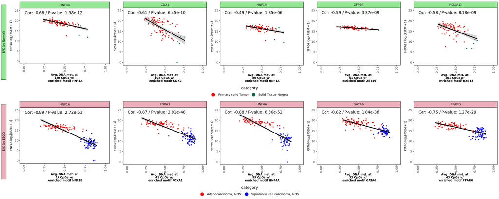

```r
analsysis.dir.esca <- unique(dirname(dir("Data/analysis_april_2019/ESCA/",recursive = T,full.names = T)))
mae <- readRDS("Data/TCGA_ESCA_MAE_distal_regions.rds")

tab.pval.esca <- tab.pval[,2:3]

suppressMessages({
library(ELMER)
library(grid)
library(ggplot2)
library(ggpubr)
library(dplyr)
})


analysis.colors <- c(
  "COAD-READ (vs Normal)" = '#ff964f',
  "EAC (vs Normal)" = '#94e894',
  "EAC (vs ESCC)" = '#eaadb9',
  "PAAD (vs Normal)" = '#9ab9f9'
)

# Top has the number of MRTF to plot
for (top in c(5)) {

  scatter.list <- list()
  scatter.grid <- list()
  scatter.labels <- c()

  for (path in analsysis.dir.esca) {
    # Load of object with enriched motifs and the probes mapped to it
    load(dir(path = path,
             pattern = "getMotif.hypo.enriched.motifs.rda",
             recursive = T,full.names = T)
    )
    i <- which(path == analsysis.dir.esca)

    tumor <- basename(dirname(dirname(dirname(path))))
    mae.plot <- mae

     # Change the data to plot based on the analysis performed
    if (grepl("Squamous",path)) {
      category <- "primary_diagnosis"
      # keep only samples used in the analysis
      mae.plot <- mae.plot[,mae.plot$primary_diagnosis %in% c("Adenocarcinoma, NOS",
                                                              "Squamous cell carcinoma, NOS") &
                             mae.plot$definition %in% c("Primary solid Tumor")]
    } else {
      category <- "definition"
      # keep only samples used in the analysis
      mae.plot <- mae.plot[,mae.plot$primary_diagnosis %in% c("Adenocarcinoma, NOS") &
                             mae.plot$definition %in% c("Primary solid Tumor","Solid Tissue Normal")]
    }
    # get top Tfs
    topTFs <- rownames(tab.pval)[head(sort(DelayedArray::rowMins(tab.pval.esca[,i,drop = F],na.rm = T),
                                           index.return = TRUE, decreasing = F)$ix, n = top)]
    topTFs <- topTFs[1:top]
    for (j in topTFs) {
      TF <- j
      scatter.labels <- c(scatter.labels,colnames(tab.pval.esca)[i])

      motif <- tf.or.table[tf.or.table$TF == j &
                             tf.or.table$analysis == colnames(tab.pval.esca)[i],"motif"][1]

      # Change the dots color based on the analysis performed
      if (grepl("Squamous",path))   color.value <- c("#FF0000","#0000FF")
      if (grepl("Adenocarcinoma.Solid.Tissue.Normal",path)) color.value <- c("#FF0000","#176d55")

      if (is.na(motif)) next

        # Plot TF expression vs avg DNA methylation of the TFBS
        suppressMessages({
          scatter <- scatter.plot(data = mae.plot,
                              correlation = TRUE,
                              byTF = list(TF = TF,
                                          probe = enriched.motif[[motif]]),
                              category = category,
                              ylim = c(0,25),
                              dots.size = 0.8,
                              color.value = color.value,
                              save = FALSE,
                              lm_line = TRUE) +
            ylab(bquote(.(TF) ~ log[2](RSEM + 1))) +
            xlab(paste0("Avg. DNA met. at \n", length(enriched.motif[[motif]]),
                    " CpGs w/ \n enriched motif ",
                    sub("_HUMAN.H11MO.[0-1].[A-D]", "",  motif))) +
            theme(legend.position = "none",
                  plot.title = element_blank(),
                  axis.title.y = element_text(size = 8, face = "bold"),
                  axis.title.x = element_text(size = 8, face = "bold"),
                  strip.background = element_rect(fill = analysis.colors[i + 1]),
                  panel.grid.major = element_blank(),
                  panel.grid.minor = element_blank(),
                  # Remove panel background
                  panel.background = element_blank()
        )
      })

      # If this is the first plot of the analysis we will add a labels (rectangle + text)
      if(j == topTFs[1]){
        gt <- gtable::gtable(widths = unit(0.5,"cm"), heights = unit(3, "in")) %>%
          gtable::gtable_add_grob(grid::rectGrob(gp=gpar(fill= analysis.colors[i + 1])), 1, 1, name = 1) %>%
          gtable::gtable_add_grob(grid::textGrob(colnames(tab.pval.esca)[i],
                                                 rot = 90,
                                                 gp = grid::gpar(fontsize = 8)), 1, 1, name = 2)
        scatter <-  scatter %>% ggpubr::annotate_figure(left = gt)
      }
      scatter.list[[paste0(i,j)]] <-  scatter

    }
    scatter.grid[[i]] <-  ggpubr::ggarrange(plotlist = scatter.list[grep(paste0("^",i),names(scatter.list))],
                                            ncol = top,
                                            # the first column should be wider since it has the label
                                            widths = c(1.15,rep(1,top - 1)),
                                            nrow = 1,
                                            common.legend = T,
                                            legend = "bottom")
  }
}
options(repr.plot.width=20, repr.plot.height=8)

# we use ggarrange to arrange the plots together
ggpubr::ggarrange(plotlist = scatter.grid,
                  ncol = 1,
                  # the first column should be wider since it has the label
                  widths = c(1.15,rep(1,top - 1)),
                  nrow = 2, # Number of analysis - rows of the plot
                  heights = c(rep(1.5,length(scatter.list) - 1), 2),
                  common.legend = F,
                  legend = "bottom")
```

# Workshop materials

## Workshops HTMLs

- ELMER data Workshop HTML: http://rpubs.com/tiagochst/elmer-data-workshop-2019
- ELMER analysis Workshop HTML: http://rpubs.com/tiagochst/ELMER_workshop
- ATAC-seq Workshop HTML: http://rpubs.com/tiagochst/atac_seq_workshop

## Workshop videos

We have a set of recorded videos, explaining some of the workshops.

- All videos playlist: https://www.youtube.com/playlist?list=PLoDzAKMJh15kNpCSIxpSuZgksZbJNfmMt
- ELMER algorithm: https://youtu.be/PzC31K9vfu0
- ELMER data: https://youtu.be/R00wG--tGo8
- ELMER analysis part1 : https://youtu.be/bcd4uyxrZCw
- ELMER analysis part2: https://youtu.be/vcJ_DSCt4Mo
- ELMER summarizing several analysis: https://youtu.be/moLeik7JjLk
- ATAC-Seq workshop: https://youtu.be/3ftZecz0lU4